# MAS2908 - Practical 05 (Solutions)

Clement Lee

Semester 2, 2025/2026

# 1 Introduction

This practical focuses on plot cosmetics, statistical transformations, incremental workflow, and logarithmic scales in `ggplot2`. You will learn how to:

- Build plots incrementally by saving them as objects
- Use `last_plot()` for interactive exploration
- Fix legend titles with `labs()`
- Use built-in themes and control font size
- Position legends
- Zoom into plots with `coord_cartesian()`
- Use logarithmic scales to reveal patterns in power law data

**Note**: The notes chapter on cosmetics covers many topics, but not all are equally important. This practical focuses on the higher-priority items. See the summary table in Chapter 6 of the notes for a full priority guide.

# 2 Incremental workflow

A powerful feature of `ggplot2` is that you can build plots incrementally. This is covered in Chapter 6.2 of the notes, but we summarise the key ideas here.

## 2.1 Saving plots as objects

You can save a ggplot as an object and add layers or scales later:

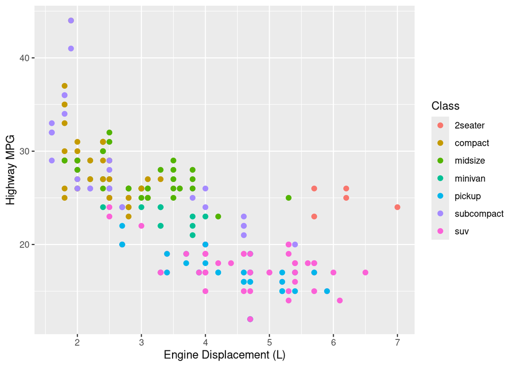

```r
# Create the base plot and save it
p <- ggplot(mpg, aes(x = displ, y = hwy, colour = class)) +
  geom_point(size = 2) +
  labs(x = "Engine Displacement (L)", y = "Highway MPG", colour = "Class")

# Display with default colours
p
```

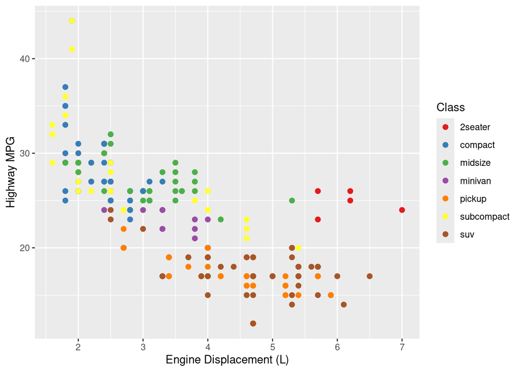

```r
# Add a different colour scale
p + scale_colour_brewer(palette = "Set1")
```

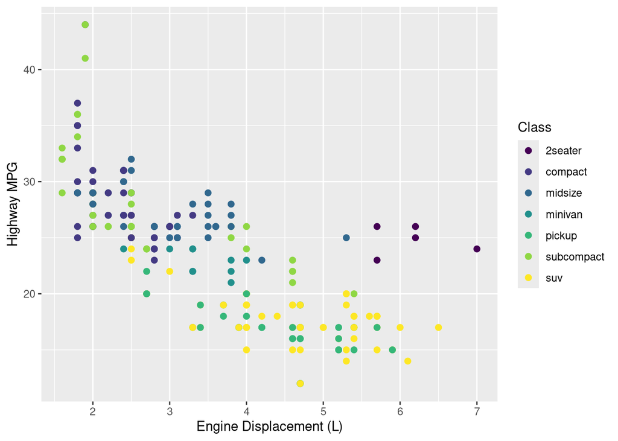

```r
# Or try viridis
p + scale_colour_viridis_d()
```

This approach makes it easy to experiment with different palettes while keeping your base plot consistent.

## 2.2 Using `last_plot()` for interactive exploration

When working interactively in RStudio (e.g., in the console or by running individual chunks), the `last_plot()` function returns the most recently created ggplot. This allows you to iteratively refine a plot without rewriting the entire code.

### 2.2.1 How `last_plot()` works

```r
# Create a basic plot
ggplot(mpg, aes(x = displ, y = hwy)) +
  geom_point()

# Add to the last plot without rewriting everything
last_plot() + labs(title = "Engine Size vs Fuel Economy")

# Continue refining
last_plot() + theme_minimal()

# Add more layers
last_plot() + geom_smooth(method = "lm")
```

### 2.2.2 When to use `last_plot()`

`last_plot()` is most useful for **interactive exploration** in RStudio:

- When you’re exploring a new dataset and want to quickly try different options
- When you’re refining aesthetics (colours, themes, labels) and want to see changes immediately
- When you’re not sure what the final plot should look like and are experimenting

**Important limitations:**

- `last_plot()` only works interactively — it won’t work reliably in R Markdown documents because the “last plot” depends on execution order
- For reproducible reports, always use the approach of saving plots as objects
- The “last plot” is reset each time you create a new ggplot

## 2.3 Exercises: Incremental workflow

1. Create a base scatterplot of `hwy` vs `cty` from the `mpg` dataset. Save it as an object `p`. Then add:
   1. A title using `labs()`
   2. A `theme_bw()` theme
   3. A colour scale for `drv` (you’ll need to add `colour = drv` to the original `aes()`)

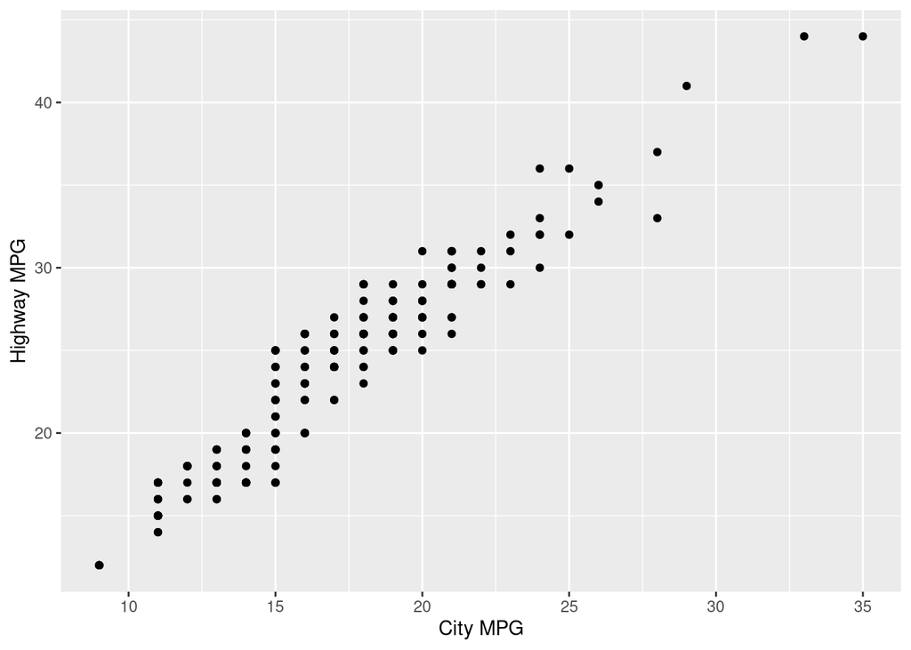

   ```r
   # Base plot
   p <- ggplot(mpg, aes(x = cty, y = hwy)) +
     geom_point() +
     labs(x = "City MPG", y = "Highway MPG")
   p
   ```

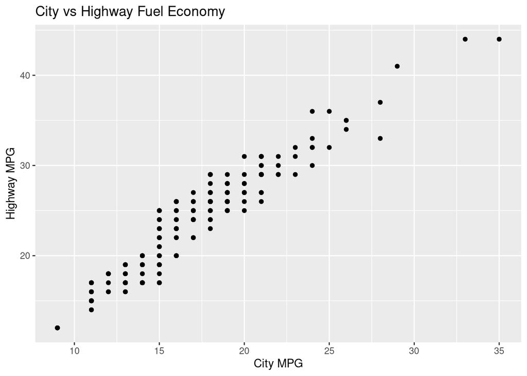

   ```r
   # Add title
   p + labs(title = "City vs Highway Fuel Economy")
   ```

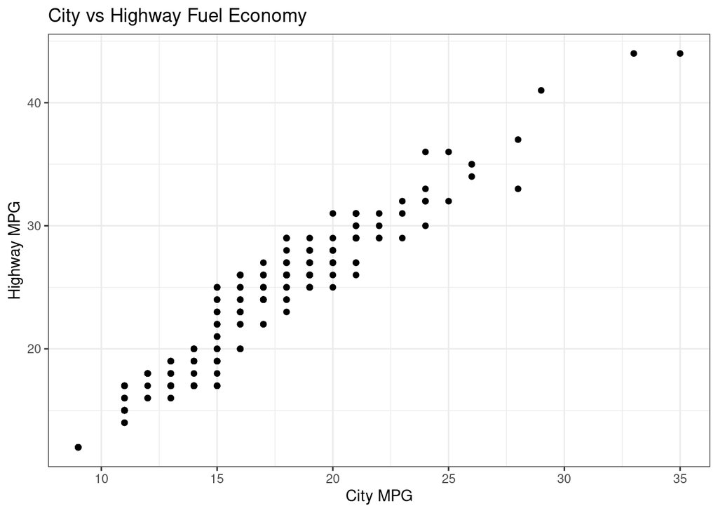

   ```r
   # Add theme
   p + labs(title = "City vs Highway Fuel Economy") + theme_bw()
   ```

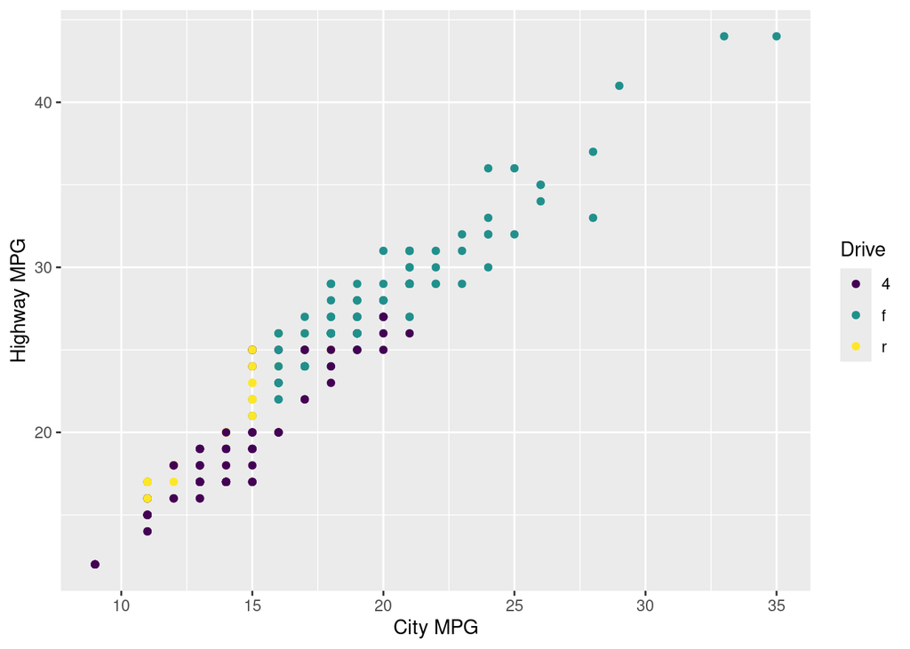

   ```r
   # With colour (need to modify base)
   p2 <- ggplot(mpg, aes(x = cty, y = hwy, colour = drv)) +
     geom_point() +
     labs(x = "City MPG", y = "Highway MPG", colour = "Drive")
   p2 + scale_colour_viridis_d()
   ```

2. In the RStudio **console** (not in a chunk), create a basic scatterplot of `hwy` vs `displ` from `mpg`. Then use `last_plot()` to:
   - Add a title
   - Change the theme to `theme_classic()`
   - Add a smooth line with `geom_smooth()`

   This exercise should be done interactively in the console. The sequence would be:

   ```r
   ggplot(mpg, aes(x = displ, y = hwy)) + geom_point()
   last_plot() + labs(title = 'Engine Size vs Fuel Economy')
   last_plot() + theme_classic()
   last_plot() + geom_smooth(method = 'lm')
   ```

3. Explain why `last_plot()` would not be appropriate for a final R Markdown report, and what approach you should use instead.

   `last_plot()` depends on execution order and the state of the R session, making it unreliable for reproducible documents. In R Markdown, chunks may be executed in different orders during development, and the ‘last plot’ could be different each time. For reproducible reports, save plots as objects (e.g., `p <- ggplot(...) + ...`) and add layers explicitly (e.g., `p + theme_minimal()`).

# 3 Plot cosmetics

## 3.1 Fixing legend titles

When you map an aesthetic to a transformed variable like `factor(cyl)`, the legend title inherits the expression literally. Use `labs()` to fix this.

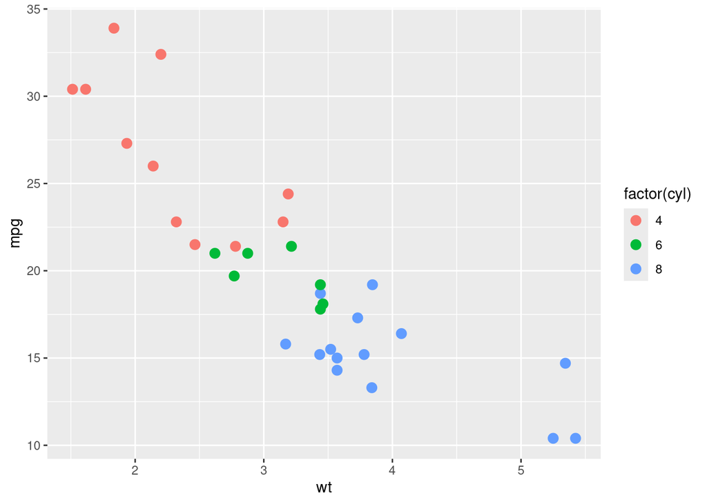

```r
# Ugly legend title
ggplot(mtcars, aes(x = wt, y = mpg, colour = factor(cyl))) +
  geom_point(size = 3)
```

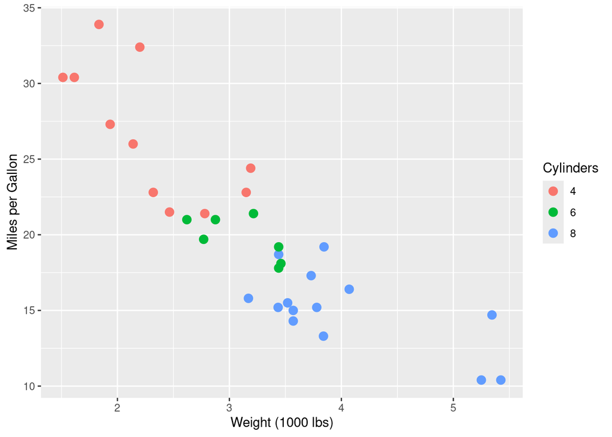

```r
# Fixed with labs()
ggplot(mtcars, aes(x = wt, y = mpg, colour = factor(cyl))) +
  geom_point(size = 3) +
  labs(x = "Weight (1000 lbs)", y = "Miles per Gallon",
       colour = "Cylinders")
```

## 3.2 Built-in themes and font size

All built-in themes accept a `base_size` argument to control font size:

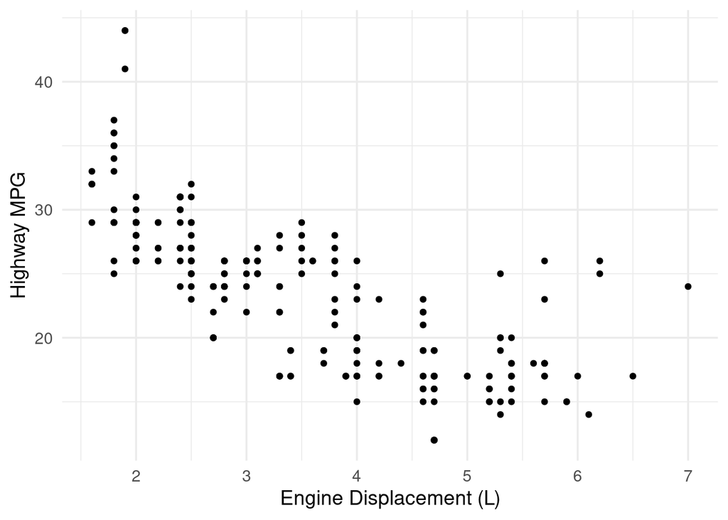

```r
p <- ggplot(mpg, aes(x = displ, y = hwy)) +
  geom_point() +
  labs(x = "Engine Displacement (L)", y = "Highway MPG")

# Larger text for readability
p + theme_minimal(base_size = 14)
```

## 3.3 Zooming with `coord_cartesian()`

Use `coord_cartesian()` to zoom into a plot without removing data. This is important when you have fitted lines or smoothers that should be computed from all data:

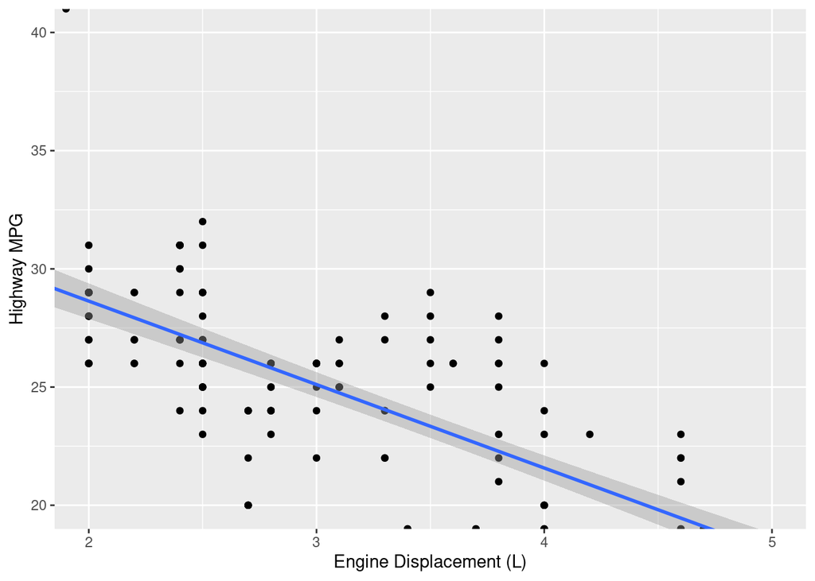

```r
ggplot(mpg, aes(x = displ, y = hwy)) +
  geom_point() +
  geom_smooth(method = "lm") +
  coord_cartesian(xlim = c(2, 5), ylim = c(20, 40)) +
  labs(x = "Engine Displacement (L)", y = "Highway MPG")
```

Compare this to using `scale_x_continuous(limits = c(2, 5))`, which would remove points outside the range and change the fitted line.

## 3.4 Exercises

4. The following plot has an ugly legend title (“factor(cyl)”). Fix it using `labs()`:

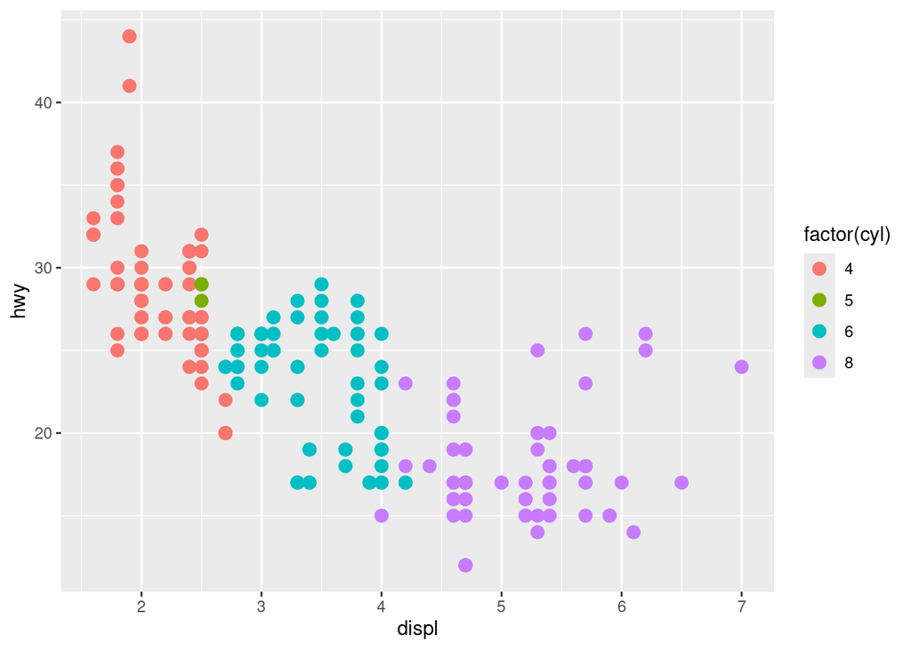

   ```r
   ggplot(mpg, aes(x = displ, y = hwy, colour = factor(cyl))) +
     geom_point(size = 3)
   ```

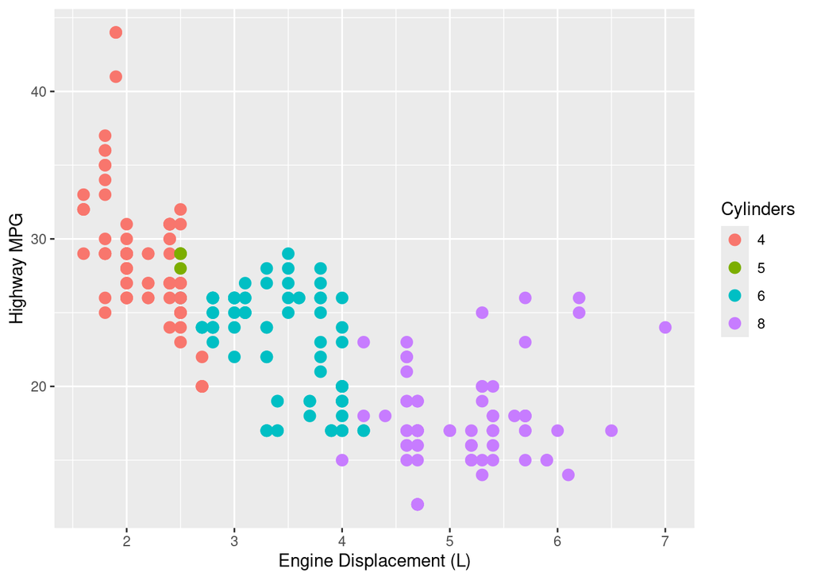

   ```r
   ggplot(mpg, aes(x = displ, y = hwy, colour = factor(cyl))) +
     geom_point(size = 3) +
     labs(x = "Engine Displacement (L)", y = "Highway MPG",
          colour = "Cylinders")
   ```

5. Using the `mpg` dataset, create a scatterplot of `hwy` vs `displ` and apply three different built-in themes, each with `base_size = 14`:
   1. `theme_bw(base_size = 14)`
   2. `theme_minimal(base_size = 14)`
   3. `theme_classic(base_size = 14)`

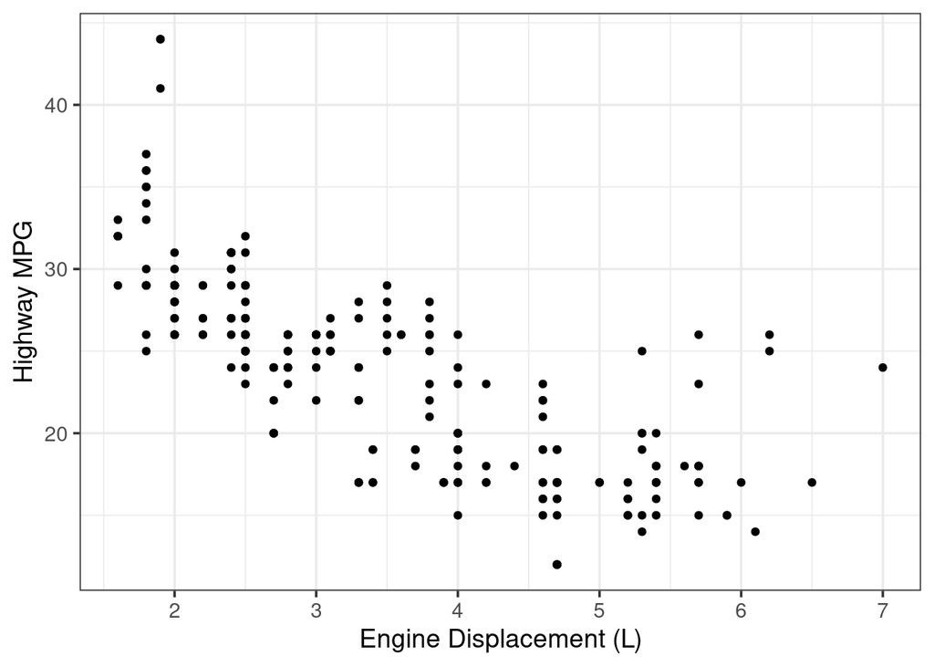

   ```r
   p <- ggplot(mpg, aes(x = displ, y = hwy)) +
     geom_point() +
     labs(x = "Engine Displacement (L)", y = "Highway MPG")

   p + theme_bw(base_size = 14)
   ```

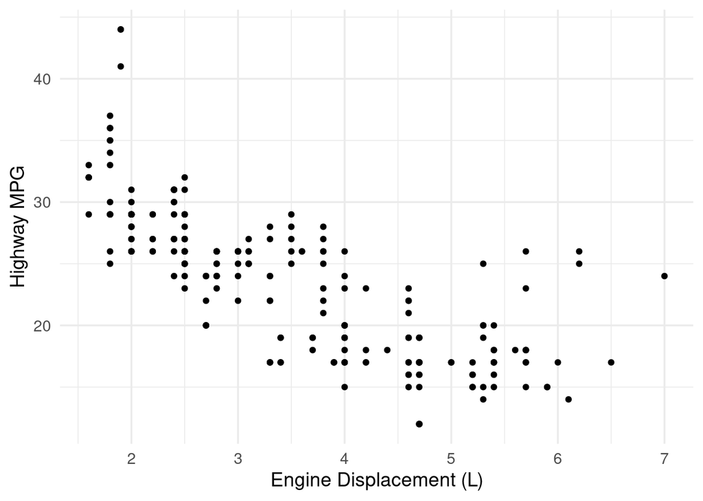

   ```r
   p + theme_minimal(base_size = 14)
   ```

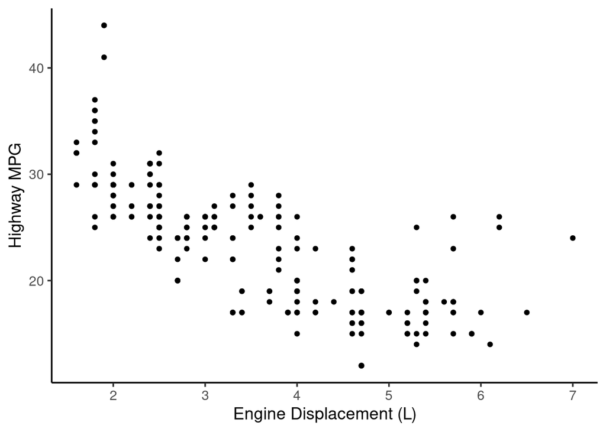

   ```r
   p + theme_classic(base_size = 14)
   ```

6. Create a scatterplot of `hwy` vs `displ` from `mpg`, coloured by `class`. Experiment with:
   1. Moving the legend to the bottom using `theme(legend.position = "bottom")`
   2. Removing the legend entirely using `theme(legend.position = "none")`

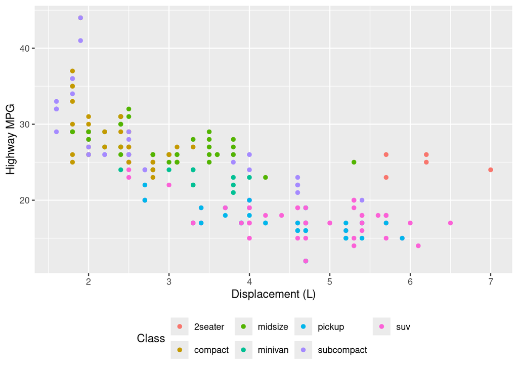

   ```r
   p <- ggplot(mpg, aes(x = displ, y = hwy, colour = class)) +
     geom_point() +
     labs(x = "Displacement (L)", y = "Highway MPG", colour = "Class")

   # Legend at bottom
   p + theme(legend.position = "bottom")
   ```

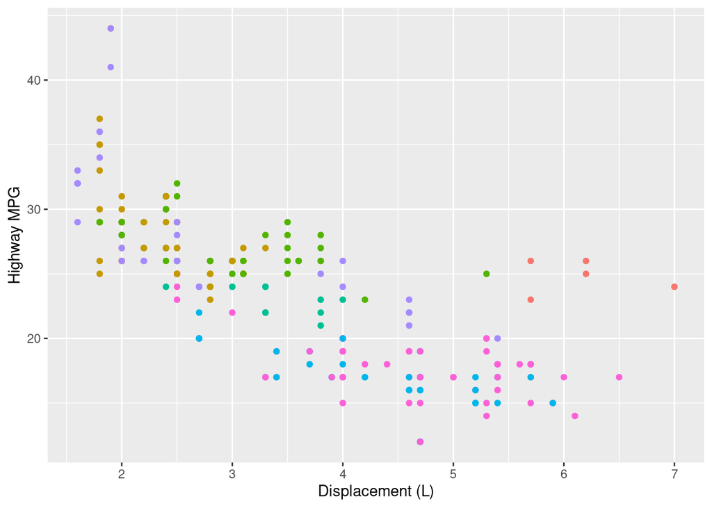

   ```r
   # No legend
   p + theme(legend.position = "none")
   ```

7. The `economics` dataset shows US unemployment (`unemploy`) over time. Create a line plot and use `coord_cartesian()` to zoom into the period from 2005 to 2015 on the $x$-axis and 5000 to 15000 on the $y$-axis.

   **Hint**: Use `as.Date()` to create date limits, e.g., `xlim = as.Date(c("2005-01-01", "2015-01-01"))`.

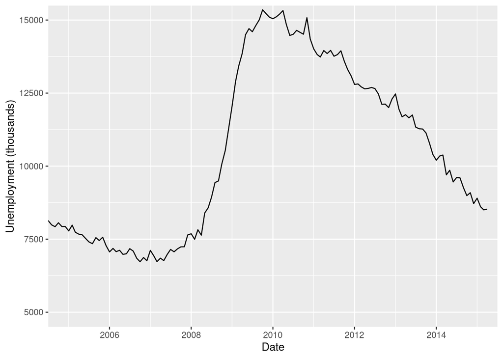

   ```r
   ggplot(economics, aes(x = date, y = unemploy)) +
     geom_line() +
     coord_cartesian(
       xlim = as.Date(c("2005-01-01", "2015-01-01")),
       ylim = c(5000, 15000)
     ) +
     labs(x = "Date", y = "Unemployment (thousands)")
   ```

# 4 Logarithmic scales

Logarithmic scales are useful when data spans several orders of magnitude or follows a multiplicative relationship. This section explores when and how to use `scale_x_log10()` and `scale_y_log10()`.

## 4.1 Power law distributions

Many real-world phenomena follow a **power law** distribution, where the probability of observing a value $x$ is proportional to $x^{-\alpha}$ for some exponent $\alpha > 1$:
$$p(x) \propto x^{-\alpha}$$

Taking logarithms of both sides:
$$\log p(x) = -\alpha \log x + \text{constant}$$

This means that on a **log-log plot** (both axes on log scale), power law data should appear as a straight line with slope $-\alpha$.

## 4.2 Exercises

13. The `poweRlaw` package contains the dataset `moby`, which records the frequency of unique words in Herman Melville’s novel *Moby Dick*. Load and examine the data:

    ```r
    data(moby, package = "poweRlaw")
    head(moby, 20)
    ```

    ```
    ##  [1] 14086  6414  6260  4573  4484  4040  2917  2483  2374  1942  1792  1744
    ## [13]  1711  1683  1674  1604  1581  1493  1372  1297
    ```

    ```r
    length(moby)
    ```

    ```
    ## [1] 18855
    ```

    This is a vector of word frequencies. Create a counted data frame showing how many words appear exactly 1 time, 2 times, 3 times, etc.

    ```r
    moby_counts <- data.frame(frequency = moby) |>
      count(frequency, name = "n_words")
    head(moby_counts, 10)
    ```

    ```
    ##    frequency n_words
    ## 1          1    9161
    ## 2          2    3085
    ## 3          3    1629
    ## 4          4     926
    ## 5          5     627
    ## 6          6     469
    ## 7          7     361
    ## 8          8     300
    ## 9          9     232
    ## 10        10     179
    ```

14. Create a scatterplot of `n_words` (number of words with that frequency) vs `frequency` on the original (linear) scale. What do you observe?

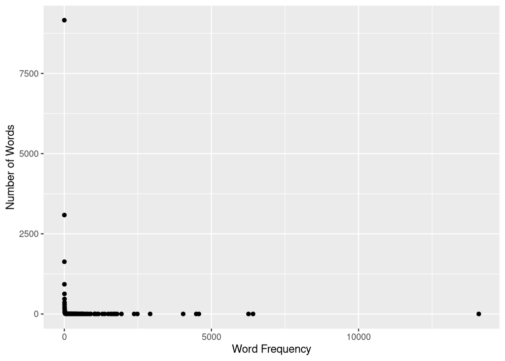

    ```r
    ggplot(moby_counts, aes(x = frequency, y = n_words)) +
      geom_point() +
      labs(x = "Word Frequency", y = "Number of Words")
    ```

    The plot shows extreme skewness: most words appear only a few times, while a few words appear very frequently. The points are heavily compressed against the axes, making it difficult to see any pattern.
15. Apply `scale_y_log10()` only. Does this straighten the relationship?

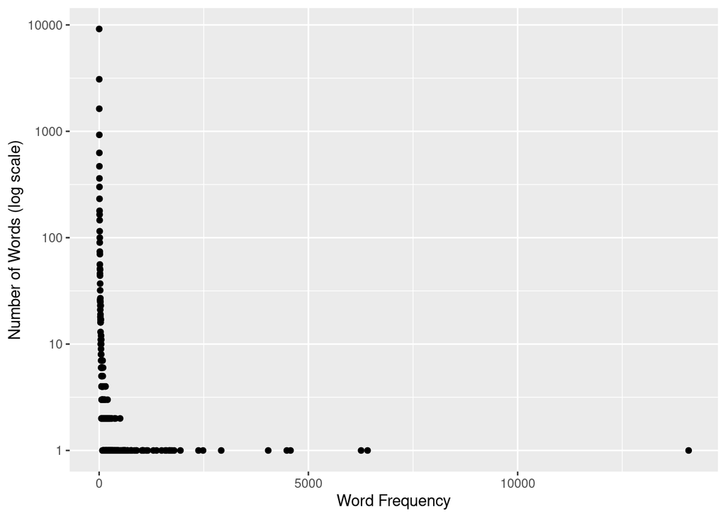

    ```r
    ggplot(moby_counts, aes(x = frequency, y = n_words)) +
      geom_point() +
      scale_y_log10() +
      labs(x = "Word Frequency", y = "Number of Words (log scale)")
    ```

    The log $y$-axis helps spread out the points vertically, but the relationship is still curved. This suggests we also need a log scale on the $x$-axis.
16. Now apply **both** `scale_x_log10()` and `scale_y_log10()`. What shape do you see? Why does this happen for power law data?

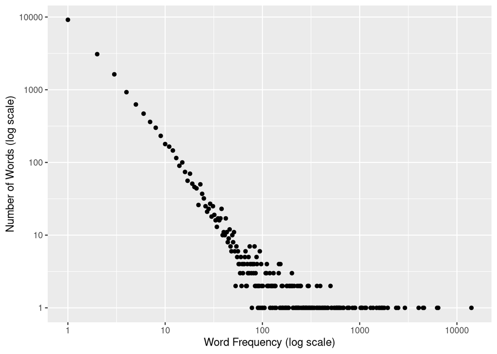

    ```r
    ggplot(moby_counts, aes(x = frequency, y = n_words)) +
      geom_point() +
      scale_x_log10() +
      scale_y_log10() +
      labs(x = "Word Frequency (log scale)", y = "Number of Words (log scale)")
    ```

    On the log-log scale, the points fall approximately on a straight line with negative slope. This is the signature of a power law distribution: $\log(\text{count}) = -\alpha \log(\text{frequency}) + \text{constant}$, which is linear in log-log space.
17. Add a linear regression line using `geom_smooth(method = "lm")` to your log-log plot. The slope of this line estimates $-\alpha$.

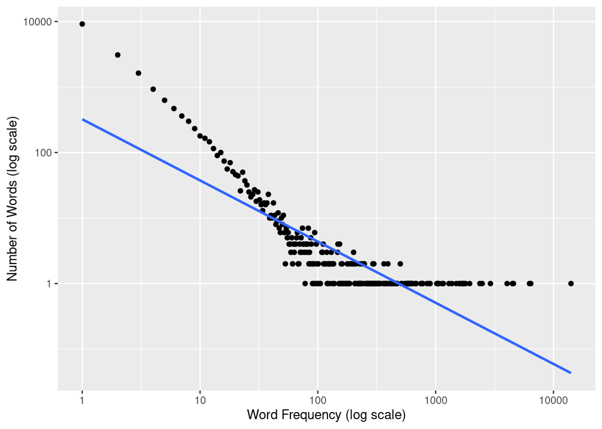

    ```r
    ggplot(moby_counts, aes(x = frequency, y = n_words)) +
      geom_point() +
      geom_smooth(method = "lm", se = FALSE) +
      scale_x_log10() +
      scale_y_log10() +
      labs(x = "Word Frequency (log scale)", y = "Number of Words (log scale)")
    ```

# 5 Summary

**Incremental workflow:**

- Save plots as objects: `p <- ggplot(...) + ...`
- Add layers or scales later: `p + theme_bw()`, `p + scale_colour_viridis_d()`
- Use `last_plot()` for interactive exploration in the console
- For reproducible reports, always save plots as objects rather than using `last_plot()`

**Cosmetics (high/medium priority):**

- Fix legend titles with `labs()`: `labs(colour = "Nice Title")`
- Use built-in themes with `base_size`: `theme_minimal(base_size = 14)`
- Position legends: `theme(legend.position = "bottom")` or `"none"`
- Zoom without removing data: `coord_cartesian(xlim = ..., ylim = ...)`

**Logarithmic scales:**

- Use `scale_x_log10()` and `scale_y_log10()` for data spanning orders of magnitude
- Power law data ($p(x) \propto x^{-\alpha}$) appears as a straight line on log-log plots
- Apply log scales to reveal patterns hidden by extreme skewness